# Relatório de Ciência de Dados e Inteligência Artificial

Karla Patrícia Oliveira Esquerre

Janaina Souza de Souza

Júlia Carolina Bijos

Sandra Pinheiro

Robson Wilson Silva Pessoa

Bruna Climaco

Luís Gustavo

Laio Luís

Nicole Príncipe

2021-12-02

# Informações gerais

## Eventos realizados com os jovens cientistas

[interactive chart not shown]

## Encontro com os novos jovens cientistas

[interactive chart not shown]

# Relatório - Ciência de Dados

## Introdução

A disciplina de introdução à ciência de dados é constituída de um propósito transformador, aproximar estudantes e escola do universo dos dados de maneira a se apropriar dos principais dados, sistemas de informação e tomada de decisões no contexto local de um grupo de discentes, docentes, comunidade escolar e de bairro.

Coordenada por uma equipe da universidade e operada num contexto à distância, neste relatório são reveladas as principais estratégias e **insights** resultado da promoção do encontro destes vários atores. Esta disciplina não é uma ilha, em paralelo a sua execução são realizadas atividades de protagonismo racial, social e de gênero, práticas investigativas e inteligência artificial. Estes temas tão atuais, tangenciam os propósitos das ciências de dados, funcionando como um mecanismo de cooperação. Uma rede de colaboradores palestrantes também enriqueceram o repertório de todos os atores que participaram do projeto, tornando a execução da discipliana de ciência de dados uma atividade punjante e transformadora do contexto social ao qual pertencem estes jovens cientistas.

Nas seções a seguir são destacadas as principais experiências vivenciadas com os estudantes participantes do projeto Ciência de Dados na Educação Pública no contexto desta disciplina. Foram realizados com os Jovens Cientistas (JC) 11 encontros dedicados apenas para ciência de dados. Parte desses encontros é resultado da proposição de um tema em 2 dias diferentes, sendo o restante constituída apenas de um encontro, contudo guiado por retornos via whatsapp.

## Metodologia

Os encontros com os estudantes foram realizados de forma online e síncrona. As atividades foram realizadas de maneira que favorecessem o diálogo entre os participantes. Com o objetivo de desenvolvimento de habilidades ligadas a ciência de dados, como a formulação de perguntas e hipóteses sobre um determinado tema, coleta e organização de dados, representação matemática por gráficos e outras visualizações de dados e por fim aplicações de elementos matemáticos e estatísticos para síntese de informações que conduzem tomada de decisão entralaçamos temas chave  
como educação, saúde, população, transportes etc. Aliado a esta abordagem sempre foram atingindos os temas transversais ligados justiça social, racial e de gênero por meio de uma estratégias que envolviam dados desagregados. Todo este cenário promove a emergência das questões ligadas às humanidades digitais, como o amplo debate gerado pelo viéses estatísticos. Nas seções a seguir são apresentados os relatos dos encontros que dão detalhes destas experiências.

[figure not shown]

## Tabela resumo de habilidades dos encontros

Nesta seção resumimos principais conceitos, habilidades e temas avaliados ao longo deste ano. Permitindo que seja alcançada uma ideia destes encontros num único olhar.

Descrição das atividades realizadas pelo equipe de Ciência de Dados.

| Encontros | Tema | Cód. Habilidade | Descrição |
| --- | --- | --- | --- |
| Introdução à Ciência de dados | Sistemas de recomendações | EMIFCG01 | Compreensão do funcionamento das tecnologias de digitais baseada em ciências de dados. |
| Coleta de dados | Programas de assistência social e distribuição de renda | EMIFMAT07 e EMIFMAT08 | Compreensão dos sistemas de coleta de dados e informações ligados aos principais programas de assistência social e redistribuição de renda. |
| Visualização de dados | Exame Nacional do Ensino Médio | EMIFMAT07 | Identificação de fatores correlacionados ao desempenho no ENEM por meio de visualização de dados. |
| Correlação e Causalidade | Capoeira e dados de futebol | EMIFMAT05 e EMIFMAT06 | Desenvolvimento de pensamento matemático e estatístico por meio do diálogo sobre manifestações culturais como capoeira. E de conceitos de causalidade e correlação por meio de análise de dados de futeb… |
| Indicadores de tendência central - Média e Mediana | Indicadores criminais | EMIFCG07 | Análise crítica de indicadores criminais suportado em visualização de dados e desenvolvimento da capacidade de síntese por meio de estatísticas. |
| Pesquisa Amostral | Sistema de transporte público e violência contra mulher | EMIFCG02 e EMIFCNT02 | Desenvolvimento de habilidades ligadas a formulação de hipóteses, planejamento e execução de pesquisas amostrais e compreensão da mobilidade e segurança da mulher. |
| Introdução à probabilidade | Pesquisa Nacional da Saúde do Escolar (PeNSE) | EMIFMAT03 e EMIFMAT06 | Representação e aquisição de vocabulários ligados a probabilidade promovendo a habilidade de transposição de conhecimento para diversas áreas. Debate ligado a saúde do estudantes por meio da pesquisa … |

## Dicussão e conclusão

O principal estrato do material dos relatos dos encontros de ciências de dados constitui-se dos pilares sobre os quais este projeto se baseou para sua realização. Os estudantes buscam a todo momento caminhos para dialogar sobre suas experiências, sendo elas as mais profundas quanto a desigualdade social. Muito embora isto seja verdade, esse também é o elemento que os posicionam num local de autoridade para tratar destes problemas. Incluímos na nossa pequena trajetória com estes incríveis jovens, informações a respeito de sistemas de redistribuição de renda e auxílio social, violência contra mulher no Estado da Bahia e a perda de mobilidade urbana em Salvador e indicadores de segurança com recortes de gênero e raça/cor. Em resumo, eles reconhecem estes temas pelo lado em que os dados não revelam com tanto clareza, trazendo uma forte base argumentativa. Por outra lado, a Ciência de Dados dá um caminho diferente, para acessar outras visões sobre estes assuntos. Esta ponte é ainda mais reforçada quando trazemos para os encontros experiências culturais que são ainda mais íntimas a estes estudantes, como a capoeira ou o debate sobre o que são os seus alimentos, seus hábitos e sua saúde. Este entralace entre desigualdade social, escancaradamente revelado nas justificativas de faltas dos estudantes participantes do projeto,  
emergem aquilo que é de conhecimento tácito, a maioria dos jovens de Salvador não estão incluídos de forma qualificada numa sociedade digitalizada. Também foi alvo de observação do projeto a necessidade que os estudantes tiveram de gerenciar o tempo devido ao retorno as aulas online e depois presencial. Alguns relataram como o volume de atividades começaram a intereferir na sua ampla capacidade de participar de todas as atividades. Os avanços observados na argumentação de alguns estudantes ao longo dos encontros, revelados na frequente utilização de vocábulos da área, contrasta com o que tipicamente se observa nos principais indicadores da educação brasileira a respeito dos avanços em disciplinas ligadas a área de exatas. Embora dados recentes revelem o crescimento do IDEB,  
por exemplo, os índices das escolas participantes estão aquém do que se espera para que o jovem alcance os elementos idealizados como uma boa educação.  
Por todo o contexto complexo da realização das atividades durante a pandemia, aliado às dificuldades relatadas pelos estudantes, a frequente participação e a exitosa realização das avaliações do projeto demonstram que é possível alcançar resultados neste tecido de interface entre os diversos atores. Num momento da história que a tecnologia digital tem que ser planejado para evitar mais um braço de desigualdade, atividades como esta são exemplos que devem ser ampliadas para um número maior de estudantes.

# Relatório de Inteligência Artificial

## Introdução

A disciplina “Inteligência artificial, a divertida mente das máquinas” imerge no universo da inteligência artificial através da experimentação e interação com ferramentas gratuitas e de fácil acesso. Sendo assim, o ensino-aprendizagem é conduzido de maneira lúdica com a confecção e interação com jogos e algoritmos baseados nos conceitos de inteligência artificial presentes nos dias atuais. Para tanto, propõe-se a estimulação do senso crítico e investigativo dos alunos através da proposição de soluções para problemas da escola e comunidade local com o auxílio da inteligência artificial, permitindo um contato direto com sua realidade e desmistificando a complexidade das tecnologias envolvidas nessa área.

## Metodologia

A disciplina de inteligência artificial é constituída de aspectos peculiares, que tornam a sua elaboração tão mais eficaz quanto mais for capaz de posicionar o estudante como aprendiz, similar às etapas de calibração do modelo de inteligência artificial. Portanto, a estratégia consiste no uso de práticas, atividades e debates nos quais cada participante atua, realiza tarefas específicas ligadas ao uso de tecnologias. Em seguida, é promovido um debate mediado pelo instrutor buscando um consenso e o respeito pelas diferentes formas de desenvolvimento das atividades. Estabelecida a natureza estatística das perspectivas de aprendizado, são experimentados recursos digitais baseados em modelos de AI que simulam comportamentos humanos, como uma conversa, capacidade de reconhecimento de desenhos ou mesmo a escrita de textos (como os casos de *fake news*). Nesta etapa o estudante é substituído por uma inteligência artificial, então é colocado na posição de observador, gestor ou num sistema cooperação. Desta relação são estimulados aos debates tão atuais entorno dos aspectos éticos e práticos dessas aplicações. Sendo enriquecido pela plena inteface com os métodos de preparação dos bancos de dados (tema mais intensamente trabalhado em Ciência de Dados) utilizados pelas IAs bem como os aspectos modernos das redes sociais e suas conexões com sistema de recomendações. Nas dinâmicas de retorno dos encontros, são realizadas atividades que desenvolvem habilidades específicas ao universo de linguagem, aprendizado e inteligência artificial por meio de ferramentas LOGO.

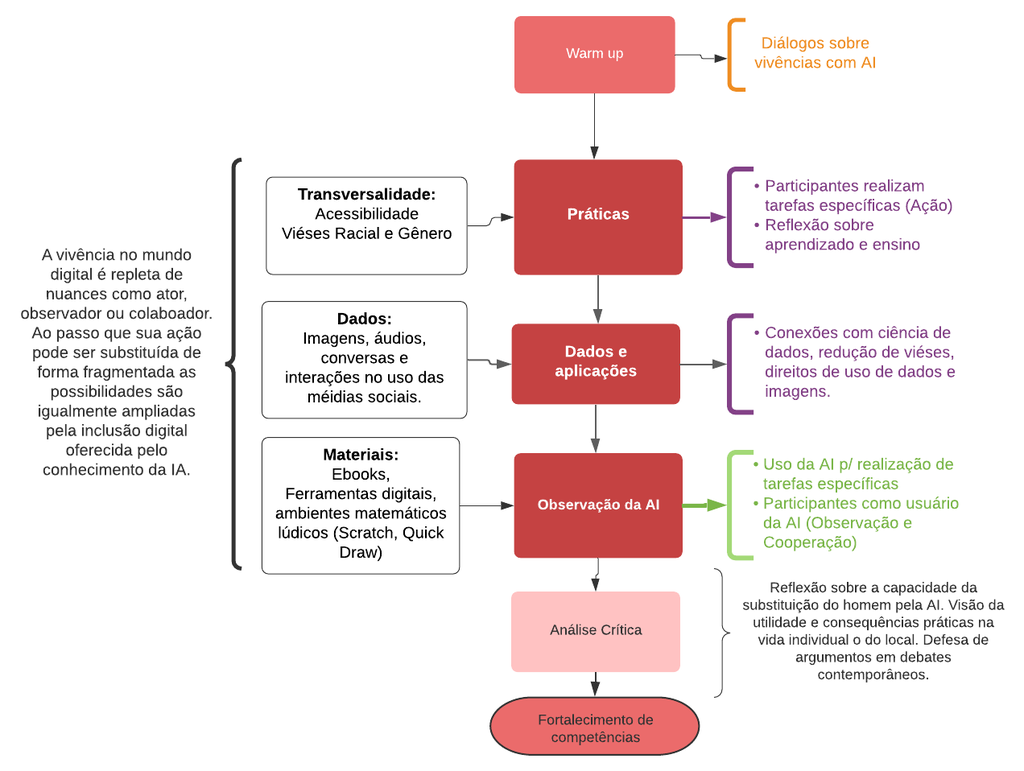

## Tabela de Habilidades e Competências

Nesta seção resumimos principais conceitos, habilidades e temas avaliados ao longo deste ano. Permitindo que seja alcançada uma ideia destes encontros num único olhar.

Descrição das atividades realizadas pelo equipe de Ciência de Dados.

| Encontros | Tema | Cód. Habilidade | Descrição |
| --- | --- | --- | --- |
| Introdução a inteligência artificial | Emprego e População | EMIFMAT01 | Compreensão da estrutura geral da inteligência artificial, por meio de ferramentas interativas e debate sobre a mudança da sociedade quanto emprego |
| Inteligência Artificial e produção de informações | Educação e Família | EMIFCNT01 | Capacidade de qualificar dados de aprendizado de máquina e julgar a qualidade das aplicações, uso da internet, produção de notícias falsas (*fake News*) e aplicações em Scratch |
| Inteligência Artificial no apoio a tomada de decisão | Saúde | EMIFCNT02 | Uso de IA no apoio de classificação nível de emergência e tomada de decisão, utilização de ferramenta online de diagnóstico e indicação de emergência. Teste de hipóteses e verificação do uso por sinto… |
| Aplicação da inteligência artificial em sistemas dinâmicosa | Transporte e mobilidade | EMIFCNT03 | Entendimento da aplicação da AI em sistemas dinâmicos com informações em tempo real. Debate sobre o uso de carros autonômos, debate sobre Big Data e aspectos tecnológicos dos sensores utilizados em ve… |

## Discussão e Conclusão

Por se tratar de uma disciplina eletiva, ligado ao campo do tecnológico e de intensa exploração do universo dos quadrinhos, pela indústria dos desenhos animados e cinema, a inteligência artificial tem sido desde os seus primórdios veiculada, alcançando os mais diversos grupos, portanto, sendo um tema familiar aos estudantes. O que torna mediação dos conteúdos de inteligência artificial bem mais abastecido de análogos lúdicos. Igualmente é a produção intensa de materiais que simulam experiências na *internet* ou mesmo nos *smartphones*, que permitem que os estudantes cheguem aos encontros de maneira mais aberta e estimulados para compreensão do seu funcionamento. Em diversas situações nos encontros, os estudantes foram capazes de sair dos experimentos e tarefas simples e generalizar o pensamento para situações extremas, por fim sendo realizado um consenso, no qual as diferentes opiniões regulavam o papel da inteligência na sociedade. Os encontros tiverem momentos que alternavam os papeis dos estudantes como atores, aqueles que realizam atividades e como usuários da inteligência artificial. Promovendo um balanço entre treinamento ou calibração de inteligências, ou uso destas ferramentas, entendo dos esforços, benefícios e fragilidades dos seus usos. Os estudantes dos dois grupos tiveram uma boa experiência nesta disciplina e foram estimulados a entrar no universo destas aplicações de maneira mais ativa pela programação de IA utilizando linguagem LOGO (Scracth). Avançando nesta trajetória, experimentaram o uso de ferramentas ligadas a saúde para diagnósticos de emergência, inclusive fizeram a verificação da ferramenta por meio de testes com sintomas padrão de algumas doenças. Demonstranto que poderiam fazer a conexão os elementos de ciência de dados. Os conceitos de inteligência artificial forte e fraca também foi amplamente debatido, demonstrando que eles podem ser futuros cientistas no aprimoramento de tais ferramentas, ainda que seja deslumbrante as tarefas que elas já realizam. Portanto, consolidando a ideia de que capacidade de fazer analogias ou transpor um conhecimento é da inteligência humana. Não obstante, tais avanços são contrapostos quando a sociedade é exposta às “fake news,” demonstrando que robôs “inteligentes” podem produzir argumentos que confundem por exemplo usuários de redes sociais, ainda que sejam oriundos de uma IA fraca. Há um grande potencial didático e pedagógico do conhecimento ligado ao da inteligência artificial. Em STEAM ela tem interfaces que permeiam desde os campos mais técnicos até àqueles ligados a filosofia dos paradigmas de aprendizagem. Outro fator motivador é sua plena presença na sociedade, o que deixa de ser apenas uma escolha de plano de ensino para tratar de questões de uma sociedade moderna.

# Encontros Ciências de Dados

## Introdução à Ciência de Dados (Turma 1)

### Relato do encontro

Especialmente para o encontro de [Introdução à Ciência de Dados](https://youtu.be/FsfJ-ERe3rI) realizado em 19/02/2021 foram notadas as seguintes observações:

- É importante ressaltar que os jovens cientistas participantes deste encontro ingressaram no projeto Ciências de Dados desde de 2019. Enquanto a equipe de facilitadores é composta de pessoas que ingressaram em 2019 e outra que iniciou em 2020.
- Todos os integrantes são formados em engenharia e um integrante no nível de graduação também em engenharia.
- Antes dos encontros de Ciência de Dados (ECD) os jovens cientistas foram estimulados à leitura prévia do ebook  
  [Uma introdução gentil à Ciência de Dados](https://bookdown.org/cienciadedadosnaep/ciencia_de_dados/).
- Considerando o **background** dos estudantes neste projeto, foi utilizada uma estratégia  
  de **brainstorm** pela construção de uma nuvem de palavras usando uma ferramenta web, assim, foram estimulados a relembrar dos principais conceitos entorno da Ciência de Dados (recomenda-se a realização de testes prévios deste tipo de estratégia com as respectivas ferramentas, para que os estudantes possam desenvolver habilidades e uma boa experiência no mundo virtual).

O diálogo no início da aula, o envio de **cards** pelos mecanismos de comunicação podem promover as lembraças dos estudantes sobre o universo da disciplina. Naturalmente, o resultado desta atividade não acaba apenas com o gráfico que contem as várias palavras. É necessário que os estudantes se envolvam na análise desta informação. Dessa maneira, ao serem impelidos a se debruçar sobre este processo, realizam a análise gráfica, uma das etapas desta ciência que seu cerne é o dado. Uma vez alcançado a visualização da nuvem de palavras, um dos instrutores  
estimulou o debate sobre quais das palavras daquela nuvem seria a de maior frequência entre aquelas fornecidas pelos próprios estudantes. Uma das estudantes rapidamente a identificou e o instrututor completou a análise, explicando a lógica daquela visualização, dada pela distribuição e dimensão das palavras, para que todo o público alcançasse um aproveitamento similar nesta etapa do encontro. Em resumo, os estudante destacaram a própria “Ciência de Dados” como expressão ou palavra da qual mais lembravam, porém, outras palavras interessntes surgiram como “Big Data,” “Insight,” “gráficos,” “medianas” etc. Contudo, a participação no chat do google meet não foi tão expressiva até esta etapa. Apesar disso, alguns elementos foram extraídos dessa etapa, como o fato de uma das estudantes fazer o relato sobre estar familiarizada com este tipo de visualização, pois assistiu no programa de televisão de “Fátima Bernardes,” evidenciando a percolação do uso de informações por outros mecanismos que não acadêmicos.

- Antes deste encontro os estudantes tiveram uma palestra na qual viram visualização de dados aplicados a análise dos dados de irradiância solar.

A partir de uma figura do meio ujbano disponibilizada no [ebook Uma introdução gentil à Ciência de Dados](https://bookdown.org/cienciadedadosnaep/ciencia_de_dados/) os estudantes são convidados a refletir sobre diversos problemas do meio urbano, como a “Saúde,” “Meio Ambiente,” “Acessibilidade” e “Transporte” e como a ciência de dados poderia ajudar. Os estudantes indicaram por meio do chat:

- “Eu acho que no geral para fazer pesquisas,”
- “Número de Leitos,”
- “Número de vagas,”
- “Demora do atendimento,”
- “Número de trabalhadores,”
- “Tem mais tecnologias para as pessoas entenderem os dados,”
- “Quantas pessoas estão internadas,”
- “Número de infectados por doenças,”
- “O sistema de marcação de exames,”
- “Quantas pessoas estão nos ônibus,”
- “O negócio que aparece onde o ônibus vai,”
- “Ter mais elevador nos ônibus pra deficiente,”
- “Ponto de ônibus,”
- “Quais são as áreas que tem menos ônibus”
- “Tipo de problema do metrô,”
- “Quantos ônibus precisam ser renovados com ar-condicionado, elevador, cadeiras etc.”

A partir deste novo “brainstorm,” o grupo é convidado a pensar como lidar com as questões formulados no âmbito da ciência de dados.

- “Dados está em todo lugar”

Os três principais pilares são então apresentados, demonstrando a interdisciplinariedade da ciência de dados (Estatística/Matemática, Computação e conhecimento do fenômeno).

Em que situação do dia a dia são encontradas aplicações de Ciência de Dados?

Relatos dos estudantes pelo chat: - Televisão, celular, internet, comerciais, jogos, informações de jornais, recomendações do Instagram, Youtube. - Coletando meus dados.

Explicação sobre sistema de recomendações.

Relato dos estudantes por audio: - Uma das estudantes desconfia que o Youtube deve fazer propagandas e recomendações para ganhar dinheiro, “não perde uma chance de ganhar dinheiro.

- Uma das estudantes diz que o youtube faz recomendações baseado naquilo que já assistimos e demonstra familiaridade ao exemplificar o caso de vídeos de *coaching* quando se pesquisa um tem associado como *empreendedorismo*.

Ao se explorar ideias mais complexas como a operação do sistema de recomendações baseado no seu perfil de redes sociais, independemtemente do aparelho em uso, eles não demonstraram familiaridade. Um possível explicação para este fato é a falta de acesso a mais de um aparelho. Em algumas situações os estudantes não tem o parelho apenas para si.

#### Mecanismo do sistema de recomendações

A instrutora demonstrou a estrutura geral do sistema de recomendações, formada pelas etapas (Usuários, Características dos Vídeos, Pre-processamento dos dados, Análise dos dados, Predição, Recomendações, Usuários).

#### Proposta de atividade em aula

Vamos criar equipes, coletar dados e responder as seguintes perguntas:

1. Qual é o gênero de vídeos favorito da sua equipe?
2. Qual é a característica mais influencia este resultado?
3. Existe um padrão no perfil dos integrantes da equipe?
- Os estudantes levaram cerca de 30min para a realização da atividade

Os instrutores identificaram que os grupos construídos no Whatsapp para a realização da atividade trocaram cerca de 100 mensagem cada.

1. grupo 4) Gênero favorito Música, o motivo é diversão, realizou a atividade chegando ao consenso, avaliação dos fatores que influenciam e inciaram a elaboração de um gráfico de setores para estudar as informações do grupo, porém ela relata que 100% das pessoas preferiram música.
2. grupo 3) Escolheram gameplay, perceberam o uso de vídeos longos 10-20min, identificaram idade entre 13-15 anos, usaram tabela para a representação.
3. grupo 2) Fizeram o descritivo das principais escolhas do grupo, e demonstram conhecimento sobre a lógica da recomendação (de acordo com o que mais assistem). Os estudantes relatam os tipos de música escutada como *Hap*. Dada a escolha distribuída entre as opções de cada um deste grupo, a única variável que os uniu era a idade. A participante do grupo ainda relata familiaridade com dados estatísticos ao dizer que seria difícil compreender o gênero de alguém como variável que definiria na recomendação devido a falta de quantidade de dados.
4. grupo 1) A equipe não podia falar, e identificaram que a eles constumam assistir vídeos com menos de 50min e a curiosidade é o que todos são

A instrutura amarra a discussão sobre as tendências dos gostos em função de algumas variáveis, quantidade de dados, identidicação de padrões por tabelas ou visualização de dados.

- Fazer perguntas
- Reuni informações (Coleta de Dados)
- Analisaram os dados
- Representação ou visualização de dados.

Nesta etapa foi amarrada a discussão do Ciclo de Dados da Ciência de Dados e novamente os estudante sãao estimulados a preencher uma nuvem de palavras com os conceitos deste encontro.

Agora, nesta etapa a nova nuvem de palavras revelou outro nível de informações. Os estudantes ficaram focados em “Coletada de Dados,” “Amostra,” “Pesquisa Trabalho em Equipe,” ““youtube’. Curiosamente, alguns estudantes relataram a palavra”protagonismos”.

### Proposta de atividade e reencontro

A construção de um formulário foi realizada para completar o ciclo e consolitar o entendimento da abordagem metodológica da Ciência de Dados. Um segundo encontro foi utilizado para debater as atividades que envolviam conceitos essenciais como ciclo de dados, coleta de dados, *insights* etc.

Neste [encontro 05/03/2021](https://youtu.be/v--UCfc3OQQ) desenvolvemos um sistemas de grupos que eram responsáveis pela elaboração de 3 perguntas baseadas na leitura de ebook, e em seguida seria realizado a proposta da pergunta para outra equipe responder. Estimulando tanto a leitura quanto a reflexão sobre a definição da Ciência de Dados.

Houve uma boa adesão a esta atividade. Tanto por parte da elaboração das perguntas quanto aqueles que decidiram respondê-las.

Os colegas interagiram, tiveram dúvidas e espontaneamente  
cooperaram uns com os outros. Explicando os mecanismos de recomendações e preferências, relataram novamente experiências com planos de celulares, o que assistiram em programas de canais de televisão a respeito sobre o sistema social da internet. Eles estavam atentos sobre a assinatura dos termos e condições utilizados na entrada de redes sociais e sites. Quando questionados quais setores da sociedade pode ser aplicado a Ciência de Dados eles souberam explicar com bastante segurança, qualquer área que envolvam dados.

## Encontro sobre Coleta de Dados (Turma 1)

### Relato do encontro

Foi realizada uma apresentação inicial  
que discutiu uma das etapas ciclo de dados, a coleta de dados. A entrata neste tema exigiu a exploração dos conceitos básicos de estruturação de dados. Portanto, estimulamos um caminho no qual os estudantes pudessem pensar sobre as diferentes formas como os dados são  
encontrados, por exemplo, como estruturados e não estruturados, categóricos, numéricos, discretos ou contínuos etc. Motivados pela necessidade de maior atuação dos estudantes, para que as perguntas e formulações partissem dos estudantes, a estrutura dos encontros passou para um modelo de dinâmicas.

Esta etapa envolvia a coleta de dados conduzidas por uma estrutura prévia que estavam pautadas no tema “Família.” Inicalmente foi indicado um conjunto de variáveis, **[Família],[Raça/Cor],[Quantidade de filhos],[Quantidade de animais de estimação]**, para o desenvolvimento da atividade, contudo não limitada a esta lista.

Nesta atividade os estudantes de cada grupo coletaram os dados e em cada linha preencheram as informações sobre as suas respectivas famílias. Algumas dúvidas interessantes surgiram, como o caso de famílias que além dos pais, tem avós ou tios. Outra informação que os estudantes tiveram dificuldade foi a escolha ou definição de raça/cor, pois não conseguiam reduzir esta informação a uma das categorias conhecidas e difundidas pelo IBGE. Na opinião de uma das estudantes havia a compreensão que sua família é mista. Esta capacidade de reflexão surge com a proposta de atividades dinâmicas como esta. Por outro lado, para trabalhar habilidades específicas, é necessário que esta dinâmica seja aperfeiçoada.

Cada grupo apresentou seus resultados, sendo que os instruturores direcionavam perguntas em relação às tabelas alcançadas pelos estudantes. Um dos principais debates surgiu entorno da necessidade de verificar a consistências dos dados por meio do cruzamento de variáveis e observações. Discutiu-se sobre variáveis numéricas e categóricas. Também foi observado um outro fenômeno, a duplicidade das linhas, demonstrando mais um possível problema tipicamente encontrado nos bancos de dados.

Em seguida, foi realizado um fechamento dos conceitos tabelas, variáveis, observações, base de dados etc.

### Proposta de atividades e reencontros

Ao final do encontro, foi proposta uma atividade na qual os estudantes teriam que escolher um candidato para vaga de emprego de motorista. Para isto deveriam definir variáveis na seleção e organizar uma base de dados para auxiliar na decisão, explicando suas decisões. Sendo importante que a principal referência seria o uso do ebook de ciência de dados.

## Reencontro sobre base dos dados e encontro de visualização de dados (Turma 1)

[encontro 30/03/2021](https://youtu.be/tT6_xB47Hssv)

### Encontro de visualização de dados

O encontro de visualização de dados utilizou o tema de educação, especificamente dedicado aos dados do ENEM.

Inicialmente foi relembrado aos estudantes que no ano anterior havia uma das disciplinas do projeto que envolvia apenas a visualização de dados.

Uma das instrutoras usou recursos de handwriting em um tablet para a construção de gráficos de barras. Primeiro demonstrou os valores na tabela da evolução do número de inscritos no ENEM. Os estudantes opinaram sobre o comportmento dos dados, o que os induziu a construção de um gráfico para explorar de forma mais direta o comportamento geral das informações.

Foram debatidos alguns conceitos básicos como eixos,representação da variável, valores de referência, legenda, título de gráficos etc.

Na etapa de análise foi explorado o comportamento do número de inscritos, exatamente oposto ao senso comum, segundo a resposta dos próprios estudantes.

Em seguida, a discussão é conduzida aos problemas de pessoas que tem dificuldade de acesso a computadores e as implicações na realização da prova do ENEM. Nesta etapa foi explorado de forma detalhada a construção de um gráfico de setores. Que envolveu o cálculo de frequência, percentual e a ideia de proporcionalidade da área do setor como representação da quantidade de uma determinada categoria.

Neste encontro a participação dos estudantes foi menos pronunciada,tanto verbalmente quanto pela escrita no chat. Este comportamento deve ser investigado, sendo que o modelo expositivo da aula ou pela dificuldade nas habilidades com cálculos com frações ou percentuais. Poucos estudantes demonstraram conhecimento prévio sobre este conteúdo.

Um dos instrutores esclarece que a motivação do uso de um gráfico ou outro depende da informação que se pretende comunicar. Também são exploradas as fragilidades dos gráficos para determinados conjuntos de dados.

## Reencontro de visualização de dados (Turma 1)

Neste [encontro](https://youtu.be/pbioaYwR89U) os conteúdos da aula anterior foram revisitados. Porém, devido as dificuldades encontradas pelos estudantes no cálculo de frações, foi utilizado um recurso de lousa matemática Mathigon que contém elementos geométricos, recursos que simulam realidades físicas como balanças, dados ou sistemas de cartas.

A apresentação do recurso digital prendeu um pouco mais a atenção dos estudantes, além de melhorar a participação e compreensão sobre as ideias de frações, fundamentais para aprofundar na análise de gráficos de setores. Uma das estudantes compreendeu detalhadamente o conceito de frações e sua ligação com o gráfico de setores, verbalizando uma ideia da visualização a qual foi estimulado a refletir.

Algumas ressalvas foram realizadas sobre aspectos de visualização de dados, como a proporcionalidade, aspectos técnicos dos eixos, percentuais de áreas ocupadas, legenda e títulos.

### Proposta de atividades e reencontros

Numa atividades proposta através de um formulário *web* os estudantes foram estimulados a responder questões sobre frações, gráficos de barras e gráficos de setores. Além disso, foi uma nova oportunidade para que os estudantes pudessem se familiarizar com informações transversais ao tema do ENEM, como a compreensão a respeito sobre os recortes de raça/cor adotadas pelo IBGE.

## Capoeira, esporte e liberdade. Correlação e causalidade (Turma 1)

O [encontro](https://youtu.be/ja7g6Z88E74) discutiu os conceitos de correlação e causalidade suportado no debate de sobre a expressão cultural local. Inicialmente foi proposta uma pequena dinâmica que envolvia a produção de uma nuvem de palavras estimulados pela experiências que os estudantes tinham a respeito da capoeira. A palavra que mais se destacou foi a “Dança,” mas os estudantes lembraram da capoeira através de vários vocábulos como:

- A arte da dança e da luta;
- Arte;
- História;
- Autodefesa;
- Cultura;
- Exercício Físico;
- Au;
- Escravos;
- Berimbau e
- África.

Na sequência, com o propósito de lembrá-los dos movimentos da capoeira foram apresentados vídeos com animações que representam a capoeira, sendo um deles construído com figuras baseada em carvão e um segundo que explora as relações de som, roda, instrumentos, movimento e a geometria com ideia de roda. Nesta etapa a participação dos estudantes se tornou mais intensa, devido a aproximação com a capoeira, conhecendo desde os movimentos da capoeira e detalhes especiais como o nome de instrumentos como atabaque, berimbau etc.

Numa etapa seguinte, os estudantes foram convidados à leitura de trechos do livro “José Moçambique e a Capoeira por Thereza de Almeida (Autor), Joaquim de Almeida (Autor), Laurabeatriz (Ilustrador) - 2007.” A leitura foi realizada por três estudantes, eram trechos que relembraram as “Instrumentos e música,” “Movimento e cooperação” e “Dinâmica, continuidade e multifuncioalidade.”

Em seguida foi demonstrado a importância da capoeira e seu destaque como patrimônio histórico cultural e as conexões da com outros patrimônios reconhecidos pela UNESCO.

A discussão é guiada inicialmente entorno da relação causal, a estrutura do berimbau e seu uso são explorados. A relação do material, da corda, a ação de tocá-la e a propagação gerada pela cabaça são o fio de construção para o conceito de causalidade. O texto é usado como base para ajudar na diferenciação entre os conceitos de causalidade e correlação. Os estudantes se sentiram confortáveis para opinar devido a reflexão baseados na vivência e experiência cultural ofericida pela cidade. Esses elementos facilitaram a entrada nas estruturas formais da matriz de causalidade. Baseado no jogo da capoeira foi construída uma matriz constituída de variáveis como movimento dos jogadores 1 e 2, movimento dos outros participantes da roda, instrumento berimbau, música. Foi definido uma legenda de cores para estabelecer três níveis de correlação, baixo (vermelho) , médio (amarelo) e alto (verde). Houve bastante cooperação nesta etapa, os estudntes transportaram as ideias discutidas nos elementos objetivos da representação da matriz de correlação.

Um segundo problema foi apresentada, baseado no futebol, que também está presente no cotidiano da maioria dos estudantes. Foi construído um [dashboard com dados de futebol](https://cienciadedadosnaep.github.io/dbesporte/), no qual foram disponibilizados gráficos de dispersão com dados de faltas, gols, posição dos jogadores etc. Esta estratégia trouxe o estudante do campo das reflexões, do debate baseado na fenomenalogia do problema (caso da capoeira) para a discussão a partir dos dados (dados de futebol). Adicionalmente, foi ampliada a discusão a respeito de correlação positiva, nula e negativa.

### Proposta de atividades e reencontros

Ao final do encontro, foi proposta uma atividade que envolvia a medição do comprimento das pernas, a altura e abertura da perna num movimento de ginga da capoeira. Assim, o estudante é estimulado a produção de suas próprias medidas, seguida da organização na forma de tabela, suportados nas experiências previamente desenvolvidas em outros encontros. Especialmente nesta atividade foram criados grupos de whatsapp para acompanhamento próximo do desenvolvimento dos estudantes, muitas dúvidas surgiram, sendo uma grande oportunidade para  
oirientá-los de acordo com suas respectivas dificuldades.

## Média e Mediana e Segurança Pública (Turma 1)

Inicialmente foi realizada uma breve revisão em relação ao último encontro, na qual os dados medidos pelos estudantes foram reunidos e disponibilizados na forma de dashboard. Alguns comentários sobre as formas como realizadas as medidas e as consequências sobre a análise final. Houve uma sequência na qual os dados originais dos estudantes foram apresentados como banco de dados, explorando mais uma vez as informações e os conceitos de observação, variáveis categoricas, variáveis numéricas e contínuas. Foi usado a estratégia de visualização de dados destas medidas para auxiliar no debate com os estudantes. Estimulando a análise crítica dos dados. Consolidando a abordagem do ciclo de dados desenvolvido no primeiro semestre. A partir da visualização dos dados os estudantes reconheceram os próprios dados e foi possível a identificação das divergências de medição.

O tema de segurança pública tão caro aos estudantes do projeto, foi apresentado numa das suas linhas de recorte racial e gênero, especialmente por meio de dados de ocorrências de crimes contra a mulher negra.

A estratégia utilizada se constituiu num vídeo de 3 min que explicava brevemente os principais indicadores de segurança pública utilizada pela Secretaria de Segurança Pública da Bahia (SSP-BA) e a possibilidade de avaliá-los por meio de média e mediana.

Na sequência, utilizando os dados da Rede Observatório de Segurança Pública sobre o número de mulheres vítimas de violência sexual na Bahia. Foi apresentado dois comportamentos destes dados entre 2009 até 2017. Alguns aspectos do contexto foram apontadas como a lei nacional no enfrentamento dessa violência é a Lei nº 11.340/2006 (Lei Maria da Penha) e Lei do Feminicídio (nº 13.104/2015) e trazidos para a compreensão dos dados e a ligação com os casos de subnotificação. O aprofundamento da questão se deu ao enxergar os dados desagregados por raça/cor.

A evolução da análise avançou pela aplicação de média e mediana, apontando as principais vantagens e desvantagens em relação aos dados. Foi proposto ao longo do encontro que os participantes escolhessem uma das categorias (Ignorados, Negras, Não Negras e Total) e fizem o cálculo da mediana. Esta atividade gerou um bom envolvimento dos estudantes, que além de realizar os cálculos souberam julgar a escolha entre média e mediana. Na sequência, os estudantes foram apresentados a mais parâmetros para a descrição dos dados. Com foco na amplitude, quartis e sua representação pelo boxplot.

Para atividade assíncrona foi proposto que os estudantes escolhessem um dos indicadores de segurança pública da SSP-BA e selecionassem apenas os valores mensais de um ano específico e calculassem a mediana, para fortalecer a habilidade de cálculo de indicadores.

## Pesquisa Amostral - Transporte (Turma 1)

Quanto ao tema de pesquisa amostral foi utilizado um texto com o título: **Em Salvador, mulheres não se sentem seguras para circular pela cidade**. Previamente, os estudantes foram questionados a respeito da segurança de andar em ônibus em Salvador. Algumas estudantes relataram a experiência de serem importunadas pelo olhar dentro do ônibus (ou no ponto) ou de outras formas.

Como a entrevista foi construída baseada em Pesquisa Amostral e era acomapanhada de excelente qualidade da visualização dos dados. Eles foram relembrados como a pesquisa amostral faz parte do ciclo dos dados apresentado no primeiro encontro.

Dessa forma, foram estimulados a pensar sobre quais foram as estratégias utilizadas para alcançar um bom resultado dessa pesquisa. Gradativamente, ao longo do rico debate com os estudantes, foram apresentas todas as etapas de planejamento e execução da pesquisa. Os estudantes foram bem assertivos na compreensão dos viéses (de seleção, medição, questão e de não respondentes) gerados pela má conduta da pesquisa amostral. Também foi discutido a importância do tamanho da amostra e a forma como a pesquisa foi realizada. Mostramos como dados de instituições públicas foram utilizados para ajudar na contextualização.

Os dados dos resultados da pesquisa são apresentados  
por meio de gráfico de setores e barras dentro de infográficos. Esta forma de apresentação  
beneficia a compreensão do dado contextualizado, suportado numa ampla discussão. À medida que este debate avançou, algumas questões tornaram-se emergentes e os estudantes reconheceram a possibilidade de serem vítimas de situações presentes no texto.

As fragilidades da pesquisa também foram exploradas ao longo da discussão, estimulando  
a reflexão do grupo sobre a qualidade do dado na formação da opinião. Finalmente, seguimos por uma breve apresentação das políticas públicas para auxiliar na solução destes problemas.

Na conclusão do encontro foi proposta uma atividade que ajudava na leitura dirigida da reportagem que traz o foco para as questões da pesquisa amostral.

## Saúde e Probabilidade - Pesquisa Nacional de Saúde do Escolar (PeNSE) (Turma 1)

Dado pelos encontros anteriores, os estudantes foram apresentados aos seguintes temas:

- Ciclo dados;
- Coleta de Dados;
- Visualização de Dados;
- Indicadores de tendência central etc.

O tema de saúde deu suporte para introdução dos estudantes aos conceitos de probabilidade. Particularmente, foi adotado o tema de saúde próximo da realidade vivida pelos estudantes. Utilizamos os dados da Pesquisa Nacional da Saúde do Escolar (PeNSE) como estratégia. As perguntas do PeNSE são adequadamente planejadas para o público dos anos finais do ensino fundamental e ensino médio o que facilitou o efetivo desenvolvimento das atividades do projeto.

O vídeo de promoção da pesquisa foi proposto aos estudantes para uma reflexão prévia. Os dados apresentados chamaram atenção dos estudantes gerando comentários a respeito de drogas, sedentarismo e hábitos alimentares. Entretanto, não foram suficientes para alcançar a noção completa de probabilidade. Assim, foi utilizado uma estratégia de construção dos conceitos como experimento aleatório, evento, espaço amostral, possibilidade e probabilidade por meio de uma estratégia tradicional baseada em elementos que os estudantes tem mais controle como dados e moedas.

Apoiado nesta discussão, avançamos na análise dos dados do PeNSE. Primeiro, os estudantes tiveram que responder um formulário elaborado a partir das perguntas do próprio PeNSE, o que permitiu avaliar a consolidação dos conceitos apresentados neste encontro.

Também foram estimulados durante o encontro a leitura de dois trechos de teses que usuram resultados  
da PeNSE. Nesta etapa do encontro, os estudantes mostraram elementos de argumentação baseado nas informações precedentes do curso. Também faz parte do vocabulário dos estudantes os outros temas debatidos em outros ambientes do projeto, especialmente aqueles ligados aos temas de protagonismo racial, social e de gênero.

## Introdução à Ciência de Dados (Turma 2)

A Turma 2, que iniciou as atividades no segundo semestre de 2021 teve um número de encontros bem menor que a Turma 1. Diferente da Turma 1, que teve a experiência com muitos encontros com a equipe desde 2020 e em alguns casos que tinham experiências presenciais em 2019.

### Relato do encontro

A proposta do encontro de introdução à ciência de dados é a mesma realizada na Turma 1. À respeito da nuvem de palavras proposta houve um resultado um pouco diferente, particularmente pela confusão entre ciência de dados e inteligência artificial.

O debate sobre decisões nos ambientes urbanos foi muito rico, houve cooperação dos estudantes com suas experiências, como a exemplificação dos problemas enfrentado ao ir para a escola, como eles usariam as informações de um celular para apoiá-los em decisões em problemas reais.

A estratégia de demonstrar a previsão do tempo colocou um contexto no qual as informações são resultado de um grande processo de análise de dados, modelagem, apresentação e tomada de decisões. Problemas emergentes como o da pandemia, trazidos pelos estudantes deram mais elementos para o debate e ajudou na definição das ciências de dados.

A qualidade da participação dos estudantes foi em média muito diferenciada, sendo necessário e também uma oportunidade de pesquisa, a compreensão das diferenças entre os grupos  
de participantes de projetos similares a este.

Com muita facilidade foi possível conectar o sistema de recomendações com o ciclo dos dados da ciência de dados.

Portanto, um excelente nível de aproveitamento de todas as partes.

# Encontros Intelig”encia Artificial

## Introdução à Inteligência Artificial

### Experiência - Jovens Cientistas

O encontro foi realizado com uma proposta inicial da ideia de Inteligência Artificial (IA) por meio de diálogo, no qual os estudantes foram estimulados a ter a primeira noção sobre o tema e compreender o seu campo aplicação.

Alguns estudantes reveleram o seu desconhecimento sobre o tema. O instrutor aproveitou uma atividade lúdica, de cunho experimental, interativo e individual para experimentar o uso desse tipo de IA. Trata-se de um recurso do google que solicita que você utilize os dedos para desenhar numa lousa *touch screen* a partir do fornecimento de uma palavra chave de objetos como mesa, relógio, carro, flechas, barcos ou de pessoas e animais. O link dessa ferramenta ([Quick Draw!](https://quickdraw.withgoogle.com/)) foi disponibilizado aos estudantes. A página faz uma provocação ao usuário,

**“Será que uma rede neural consegue aprender a reconhecer seus desenhos?”**,

a partir desse texto, o instrutor mergulha em mais provocações aos estudantes, explorando a ideia da palavra neural e sua inspiração no campo da biologia. É discutida a capacidade da máquina aprender, ainda sem relativizar a relação entre a inteligência humana e de máquina. Então é sugerido o teste da ferramenta para o que estudante possa avaliar se fato a máquina pode ou não aprender com os desenhos de uma pessoa. Cada estudante com seu link foi submetido a palavras diferentes de forma automática pela ferramenta e tiveram 20 segundos para desenhar cada proposta. A medida que o desenho é realizado e você confirma que a ferramenta acertou, a rede neural recebe um reforço pela confirmação do acerto. Essa dinâmica foi proposta como uma ideia de diversão, de jogo. Foi demonstrado aos estudantes que os desenhos que a rede neural não conseguiu adivinhar pode ainda ser estudado. Assim, a partir dessa análise o estudante começa a compreender que há um grande banco de imagens de referência que a ferramenta utiliza para tentar adivinhar e que ela usa uma análise de semelhança para reconhecer qual é o objeto idealizado por trás do esboço feito pelo usuário. Um esboço com pouco especificidade pode gerar confusão para a rede neural. Em seguida, foi explicado que a máquina precisa de um conjunto de exemplos para aprender o que são os objetos e diante da apresentação de vários exemplos parecidos temos um certo limite para reconhecer um objeto. O instrutor ainda provoca o exercício de demonstrar esta atividade para algum parente e questioná-lo se é uma pessoa que está adivinhando ou máquina.

Neste ponto do encontro os estudantes ficaram mais abertos a interação, relataram a ideia de que em alguns jogos há um robô inteligente competindo contra eles. Outra estudante espontaneamente traz a palavra algorítimo para o diálogo, revelando a conexão da ideia do aprendizado de máquina a uma série de regras e procedimentos que mimetizam uma forma de aprendizado.

Ao final desta etapa, foi proposto que cada estudante indicasse o número de acertos que a ferramenta alcançou, utilizando uma ferramenta do slido que centraliza as respostas  
e constrói um histograma. A partir deste conjunto os estudantes foram estimulados a discutir por uma perspectiva estatística sobre a capacidade da máquina de  
inferir a definição do desenho por meio do esboço.

É importante salientar que este pequeno experimento promove aos estudante uma visão completa de aprendizado supervisionado, ainda que não tenha permeado por conteúdos matemáticos e estatísticos1 avançados. Apenas a interface, a ideia de comparação, similiaridade , reconhecimento e pouco de analogia ao comportamento de aprendizado biológico, permitiram que o estudante desenvolvesse esses elementos cognitivos da inteligência artificial.

Depois de ter experimentado a ferramenta os estudantes começaram a escrever no chat porque a rede neural acerta ou erra:

- “Ela acerta porque já viu o desenho antes!”
- “Erra porque o desenho não foi bem feito!”
- “Ela erra porque não tem conhecimento sobre aquilo que foi demonstrado!”

O instrutor explorou um dos desenhos, mostrando que para que um determinado desenho fosse reconhecido era necessário que ele mantivesse características presentes nos desenhos que compõem o banco de imagens de referência da rede neural. Também foi demonstrado que se algumas características fogem do padrão, mas se assemelham a outro objeto pode levar a classificação equivocada do objeto, também percebido anteriormente por uam das estudantes.

A medida que o encontro evoluiu, o vocabulário de área de inteligência artificial foi sendo introduzido e argumentação dos estudantes começou a ser baseada nestes termos.

O instrututor ainda destaca que para uma imagem pertencer ao banco de imagens de referência é necessário que muitas pessoas tenham desenhado de forma similar, o que torna esta imagem elegível ao banco de dados.

Neste novo ciclo do encontro, o instrutor novamente explora a análise crítica dos estudantes, pedindo para votarem a respeito da capacidade da IA ser uma boa juíza sobre desenhos. A maioiria votou que a IA seria uma excelente juíza de desenhos. Na avaliação por chat de um dos estudantes a inteligência artificial não tem conhecimento sobre alguns detalhes e portanto não mereceria uma nota excelente para julgar esta atividade. Chegando a conclusão que ela não é perfeita.

Vocábulos como:

- treina;
- acerta;
- erra;
- aprende;
- imitar;
- modelo;
- engrenagem;
- algorítimo;
- rede neural;

ajudam na definição mais formal da inteligência artificial:

**É a capacidade da máquina funcionar de maneira ao raciocínio humano.**

**Aprendizagem de máquina basea-se na capacidade de aprender com os dados.**

Ainda nesta etapa, por meio slido, os estudantes foram estimulados a indicar palavras para gerar nuvem de palavras a respeito das aplicações de IA. Algumas palavras escolhidas pelos estudantes chamaram atenção como “Celular,” “Redes Sociais,” “Facebook,” “Youtube,” “Netflix” e “Intagram,” “Xbox” e “Internet.” Devido ao universo de palavras, as questões sobre o sistema de recomendações emergiram, de forma similar a discussão gerada na discipliana de Ciência de Dados. O instrututor ainda comenta que as 50 milhões do Google  
estão disponíveis para o desenvolvimento de variadas aplicações.

A última demonstração do encontro consistiu na apresentação do [Scratch](https://hackeduca.github.io/) numa versão mais avançada que aquela experimentada pelos estudantes no ano anterior. O instrutor demonstrou alguns ambientes e  
funcionalidades do Scratch. Especialmente foi apresentado a possibilidade de desenvolver uma aplicação de IA utilizando o *TensorFlow K-NN* sendo a atividade foco do encontro de retomada da próxima aula.

### Experiência Novos Jovens Cientistas

A aula de introdução de IA realizada com os Novos Jovens Cientistas sofreu alterações em relação a primeira aula realizada com o grupo Jovens Cientistas (JC). As primeiras etapas foram guiadas da mesma maneira, entretanto, depois de todo ciclo com [Quick Draw!](https://quickdraw.withgoogle.com/) foi inserido um debate a respeito da força da inteligência artificial.

É demonstrado que a inteligência artificial fraca tem alta capacidade de realizar atividades especificas, enquanto que a ideia de uma inteligência artificial forte está ligada a capacidade de assimilar, classificar e produzir uma série de conteúdos e informações. Este paralelo envolveu os estudantes num intenso debate, ao ponto deles se comportarem de maneira muito confortável, buscando referência nos seus filmes favoritos, por exemplo, “Vingadores.” Eles começaram a formular diversas situações nas quais equipamentos pudessem ter inteligência artificial forte ao ponto inclusive de reinvindicarem respeito.

Uma outra mudança do encontro dos NJC em relação ao realizado com JC que deixou alguns estudantes surpresos foi a capacidade do [Google Assistente](https://assistant.google.com/intl/pt_br/) em agendar compromissos pelo usuário, simulando que é uma pessoa. No vídeo utilizado, a transação é realizada sem quaisquer falhas. Frases dos estudantes:

-“Eu tenho que testar isto!” -“Incrível!” -“Geente!”

Em seguida, aproveitando a discussão do vídeo, eles foram provocados a responder no ambiente do slido **“Quais profissões você acha que estão ameaçadas pela IA?”**. Alguns estudantes refletiram além da proposta, ao ponto de sugerir que haveria a esperança da existência de um exterminador do futuro. Outros disseram:

- “Professor, concordo com quem diz que todas as profissões estão ameçadas. Se a internet acabar todos estão perdidos.”
- “A internet agora é oxigênio, daqui a pouco os carros viram robô.

A discussão foi amarrada pelo instrutor que conclui que a maioria das profissões ameaçadas são aquelas que estão ligadas a inteligência artificial fraca. Enquanto que outras profissões serão cada vez mais necessárias.

Os estudantes ainda forneceram diversos outros exemplos com os quais interagiram ou refletiram, como a capacidade da inteligência artificial do Bradesco de identificar termos inapropriados. O professor mostrou as campanhas contra assédio por meio de IA.

Em outras situação uma estudante vai mais a fundo na reflexão sobre empregos, alcançando uma ideia de sociedade em guerra com máquinas, ao pensar que as máquinas dominariam todas as atividades de trabalho e finalmente o que seria do homem?

O instrutor conduz um pensamento sobre  
a necessidade de dados de boa qualidade e a importância do cientista de dados para evitar viéses dos modelos de IA.

Uma estudante faz uma analogia ao final do encontro, dizendo que “a IA ainda é limitada pois não capaz de se reprogramar, da mesma forma como não poderíamos mudar o nosso cérebro.”

## Fato ou Fake?

Os avanços tecnológicos e a ampliação do universo de comunicação seja pela mídia jornalística ou redes sociais traz benefícios incontestáveis, entretanto, o efeito colateral desse amplo acesso é o surgimento de mecanismos de produção de notícias falsas. Neste encontro os estudantes foram provocados como a mídia digital está sujeita a estes ataques e como é possível a utilização de inteligência artificial para ajudar no combate deste universo.

O encontro foi conduzido inicialmente pela elaboração de um jogo operado na plataforma [Kahoot!](https://kahoot.com/), no qual os estudantes foram estimulados a responder sobre notícias que são fato ou que são fake.

- Animais de estimação podem transmitir COVID-19 aos humanos.
- Por engano mulher rezava para boneco do “Senhor dos Anéis.”
- Pedro Alvarez Cabral descobriu o Brasil.
- DNA do homem é $50\%$ idêntico ao DNA da Banana.
- Participantes de um programa *reality* passam um ano isolados, mas apenas parte do programa foi exibido.
- Medir neurônios pela testa mata neurônios.
- Universidade cria museu de memes.
- Usar álcool gel nas mãos para prevenção da COVID-19, altera o resultado no teste do bafômetro em blitze.

Dessa maneira, os estudantes são colocados na posição de decisão, similar a função que se pretendia discutir nas etapas posteriores sobre o papel da inteligência artificial em nos apoiar em decisões sobre a veracidade de informações da internet ou redes sociais.

Para auxiliar nesta reflexão foi solicitado aos estudantes que indicassem quais melhores práticas para evitar as notícias falsas. Alguns estudantes indicaram a seguintes práticas para indicar se é ou não a *fake news*:

- “Procurar se as fontes as fontes são seguras.”
- “Pesquisar, analisar a fonte.”

O instrutor indicou as seguintes práticas:

- erros ortográficos;
- concordâncias erradas;
- verificar se as informações desatualizadas;
- suspeitar da forma de difusão da informação que são acompanhadas de estímulos de compartilhamento;
- duvidar de notícias alarmistas.

Depois de uma ampla discussão sobre a veracidade de notícias, foi gerado uma prática no [slido](http://slido.com) que solicitava quem eram as pessoas conhecidas ou parentes que mais compartilham “fake news.” Em geral, “Mãe” e “Grupo da Família” chamam muito atenção. Na opinião dos estudantes os pais e avós que não cresceram com uso de tecnologia tem mais dificuldade em determinar se uma notícia é ou não *fake news*. Chegaram a conclusão que pessoas com o menor grau de educação tem mais dificuldade em decidir sobre a veracidade das notícias. Também foi explorado qual a região do país que mais acreditam em *fake news* a respeito de COVID-19.

Finalmente, depois de contextualizá-los, foi proposto o debate sobre a aplicação da inteligência artificial na identificação de *fake news*. Por meio do resultado de uma pesquisa que desenvolveu um aplicação AI que aprende a construir *fake news* para em seguida decidir o que era ou não *fake news*, os estudantes passaram a notar que o papel de decisão assumidos por eles na primeira etapa do do encontro, agora estava automatizado.

Para demonstrar o potencial do ferramental de AI que  
para a produção de *fake news*, foi demonstrado o conceito de “deepfake” no qual foi exemplificado pelo app deepface. Demonstrando como pode ser divertido e igualmente arriscado, podendo intereferir na vida de indivíduos e até mesmo na relação entre países, por exemplo com a produção de aúdios falsos associados a políticos.

Para a compreensão do mecanismos de funcionamento da construção de frases por meio de IA foi apresentado um diagrama esquemático constituído das principais etapas:

- Banco de palavras chave;
- Conversão de palavras em números;
- Combinação dos números;
- Classificação, atribuição de rótulo.

Um pequeno debate sobre a importância da escolha de verbos, substântivos e de maneira indireta a respeito da semântica entorno da construção e identificação de *fake news*.

Para que os estudantes não construam de maneira equivocada a ideia de que a IA é um algorítimo utilizado apenas para a construção de *fake news*, por meio do uso do [Scratch - Positividade](https://scratch.mit.edu/projects/510980026), desenvolvido pelo instrutor, os estudantes tiveram a experiência do uso de um gerador de positividade. Um algorítimo que contém um banco de frases que são combinadas de forma aleatória. Os estudantes foram estimulados a preencher um formulário para tornar este “robô” mais inteligente. A medida que as frases são emitidas o usuário as avalia como “gostei” ou “não gostei” reforçando o aprendizado.